# Alexander Dank Curriculum vitae

# Over mij

**Persoonlijke drive**— Mijn passie voor data is tijdens mijn PhD project geboren; het analyseren van grote datasets, ontrafelen van (biologisch relevante) patronen en visualiseren van ons werk kon niet zonder programmeren. Gedreven door curiositeit en met het oog op transparant rapporteren heb ik ervaring opgedaan in verschillende codeertalen (R, Python, LaTeX, Rmarkdown, R shiny Apps). Zelfs mijn dissertatie (en deze CV) is compleet in Rmarkdown geschreven! Ik kan niet wachten op mijn volgende data uitdaging.

# Contact

[output not shown]

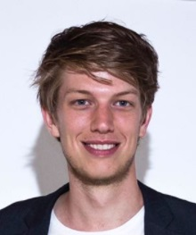

# Werkervaring

| year | what |
| --- | --- |
| 2018 — 2023 | PhD Food Biotechnology, Wageningen University and Research |
| 2017 — 2017 | Studentassistent, Wageningen University and Research |
| 2015 — 2018 | Baliemedewerker universitair sportcentrum, Sportcentrum De Bongerd |
| 2014 — 2016 | Trainer & coach mentoren, Introductieweek Wageningen Universiteit |
| 2014 — 2015 | Bestuursjaar sportstichting, SWU Thymos |
| 2014 — 2015 | Woordvoerder decanendagen, Wageningen University and Research |

# Codeertalen

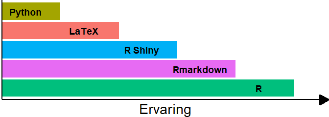

[figure not shown]

- [Shiny web app development voorbeeld](https://foodmicrobiologywur.shinyapps.io/Hazards_shiny/)

[figure not shown]

- [Code voorbeelden](https://github.com/alexanderdank/RvIG_sollicitatie)

[figure not shown]

- [Lijst van gevolgde cursussen](https://docs.google.com/spreadsheets/d/e/2PACX-1vRPu82jrnjNelp5ULiIUjkNw7CdW9zowWb5H--ytSvSrbwEWk47HoAdDpCG3Pam9An62kh5uE8Xx73q/pubhtml)

# Wetenschappelijke publicaties

- [Dank, Smid, and Notebaart (2018)](https://link.springer.com/article/10.1186/s13104-018-3788-5)
- [Dank, Mastrigt, Yang, et al. (2021)](https://www.sciencedirect.com/science/article/abs/pii/S0023643821001948)
- [Dank, Zeng, et al. (2021)](https://www.frontiersin.org/articles/10.3389/fmicb.2021.679827/full)
- [Dank, Mastrigt, Boeren, et al. (2021)](https://ami-journals.onlinelibrary.wiley.com/doi/full/10.1111/1462-2920.15532)
- [Zeng et al. (2022)](https://www.sciencedirect.com/science/article/abs/pii/S2214799321001570)
- PhD thesis — *Propionibacterium freudenreichii*, more than meets the ‘eyes’

# Opleiding

| year | what |
| --- | --- |
| 2006 — 2012 | Gymnasium, Waalwijk |
| 2012 — 2016 | BSc Food Technology, Wageningen |
| 2016 — 2018 | MSc Food Technology (cum laude), Wageningen |
| 2016 — 2017 | Erasmus KU Leuven, Leuven |
| 2018 — 2023 | PhD Food Biotechnology, Wageningen |
| 2018 — 2018 | Internship Arla Foods (9/10), Aarhus |

# Presentaties en conferenties

| year | what |
| --- | --- |
| 2017 | De complexe wereld van gefermenteerde zuivel – Najaarssymposium 2017, Genootschap ter bevordering van melkkunde |
| 2018 | FEMS 2018 conferentie+presentatie, Federation of European Microbiological Societies |
| 2018 | The Brave New World of Smart Data & Semantics in the Life Sciences, Laboratory of Systems and synthethic biology, WUR |
| 2019 | Organisatie Young EFFoST dag 2019, European Federation of Food Science and Technology |
| 2019 | EFFoST conferentie 2019, European Federation of Food Science and Technology |
| 2019 | Food Science symposium presentatie, VLAG |
| 2021 | Ecophysiology of food related microbes presentatie, VLAG |
| 2022 | National biotechnology congress, Nationale biotechnology vereniging |
| 2023 | National proteomics platform 2023 presentatie, Koninklijke Nederlandse Chemische Vereniging |